# Práctica 3 Ejercicios

Estimación Puntual de Parámetros y Bondad de Ajuste

Juan Luis Herreros Bódalo

Versión 01-enero-2021

# Ejercicio 1

Dados los datos de la muestra que aparece en *ajusta.ejercicio1.txt*, se pide:

1. Estimar el parámetro $p$ de una distribución binomial con $n=8$ y el error estándar de dicha estimación.
2. Obtener una representación gráfica que permita valorar la bondad del ajuste.
3. Realizar un contraste de bondad de ajuste y decidir si el ajuste mediante la distribución binomial es aceptable.

## Estimación del parámetro

Primero, importamos los datos.

```r
datos.binom <- read.delim("ajusta.ejercicio1.txt")
summary(datos.binom)
```

```
##        x
##  Min.   :0.000
##  1st Qu.:1.000
##  Median :1.000
##  Mean   :1.387
##  3rd Qu.:2.000
##  Max.   :5.000
```

La estimación MLE de $p$ en una distribución $B(8, p)$ es $\hat{p} = \bar{x}/8$:

```r
print(p.est <- mean(datos.binom$x) / 8)
```

```
## [1] 0.1733333
```

## Error estándar

Viene dada por $s.e.(\hat{p}) \approx \sqrt \frac{\hat{p}(1-\hat{p})}{N}$:

```r
sqrt(p.est * (1 - p.est) / length(datos.binom$x))
```

```
## [1] 0.04370948
```

Así que tenemos una estimación del parámetro de 0.17, con un error estandar estimado de 0.04.

## Bondad del ajuste

Por tanto, estamos diciendo que para los datos de la muestra creemos que un ajuste adecuado puede ser el que proporciona una distribución binomial de parámetros $n=8$ y $p=$ 0.17. Lo que nos preocupa ahora es valorar si, en efecto, ese ajuste es adecuado o no.

En primer lugar, vamos a representar gráficamente un diagrama de barras y, sobre él, vamos a añadir las frecuencias esperadas según el modelo binomial ajustado:

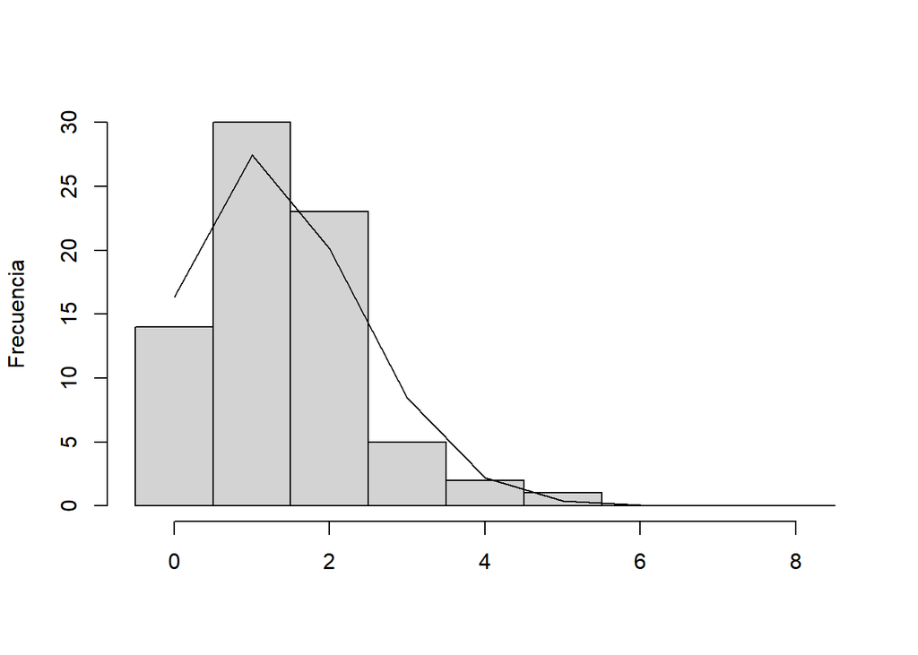

```r
# Puntos de corte para el histograma
ptos.corte <- -0.5:8.5
# Diagrama de barras
diagrama.binom <- hist(datos.binom$x, breaks = ptos.corte, main = "", xlab = "", ylab = "Frecuencia")
# Función masa del ajuste
x <- 0:8
num.datos <- length(datos.binom$x)
y <- num.datos * dbinom(0:8, 8, p.est)
lines(x, y)
```

Ese gráfico muestra semejanzas entre las frecuencias de valores en la muestra,

```r
diagrama.binom$counts
```

```
## [1] 14 30 23  5  2  1  0  0  0
```

y la frecuencia de valores que el modelo dice que debería haber,

```r
round(num.datos * dbinom(0:8, 8, p.est), 2)
```

```
## [1] 16.36 27.44 20.14  8.44  2.21  0.37  0.04  0.00  0.00
```

Por ejemplo, tenemos 2 cuatros, y el modelo dice que debería haber también alrededor de 2 (frecuencia esperada 2.21).

Ahora bien, esas similitudes ¿son suficientes para afirmar que el ajuste es adecuado? La respuesta la proporciona el contraste de bondad de ajuste.

## Contraste de bondad de ajuste

```r
# Probabilidades que da la función masa ajustada:
probs <- dbinom(0:8, 8, p.est)
# Contraste de bondad de ajuste
print(gof <- chisq.test(diagrama.binom$counts, p = probs, simulate.p.value = TRUE))
```

```
##
##  Chi-squared test for given probabilities with simulated p-value (based
##  on 2000 replicates)
##
## data:  diagrama.binom$counts
## X-squared = 3.5179, df = NA, p-value = 0.6212
```

Como podemos ver, el valor del estadístico es 3.52 y, dado que el p-valor es 0.62, ese valor está claramente por debajo del percentil 95, así que nuestro ajuste, como se intuía en el gráfico, es aceptable.

# Ejercicio 2

Dados los datos de la muestra que aparece en *ajusta.ejercicio2.txt*, se pide:

1. Estimar los parámetros de distribuciones Poisson, geométrica y binomial negativa y sus errores estándar.
2. Obtener representaciones gráficas (en la misma figura) que permitan valorar la bondad de los ajustes.
3. Realizar contrastes de bondad de ajuste para decidir cuáles de los ajustes son aceptables y cuál es el más adecuado para los datos.

## Estimación de los parámetros y sus errores estándar

Importamos los datos.

```r
datos.ej2 <- read.delim("ajusta.ejercicio2.txt")
summary(datos.ej2)
```

```
##        x
##  Min.   : 0.000
##  1st Qu.: 2.000
##  Median : 3.000
##  Mean   : 4.004
##  3rd Qu.: 6.000
##  Max.   :16.000
```

### Poisson

#### Estimación del parámetro

La estimación MLE de $\lambda$ en una distribución $P(\lambda)$ es $\hat{\lambda} = \bar{x}$:

```r
print(lam.estp <- mean(datos.ej2$x))
```

```
## [1] 4.004
```

#### Error estándar

Viene dada por $s.e.(\hat{\lambda}) \approx \frac{s_{N-1}}{\sqrt N}$:

```r
sd(datos.ej2$x) / sqrt(length(datos.ej2$x))
```

```
## [1] 0.2083786
```

Así que tenemos una estimación del parámetro de 4.004, con un error estandar estimado de 0.21.

### Geométrica

#### Estimación del parámetro

La estimación MLE de $p$ en una distribución $Geo(p)$ es $\hat{p} = \frac{1}{1 + \bar{x}}$:

```r
print(p.estg <- 1 / (1 + mean(datos.ej2$x)))
```

```
## [1] 0.1998401
```

#### Error estándar

Viene dada por $s.e.(\hat{p}) \approx \sqrt \frac{\hat{p}(1-\hat{p})}{N}$:

```r
sqrt(p.estg * (1 - p.estg) / length(datos.ej2$x))
```

```
## [1] 0.02529063
```

Así que tenemos una estimación de la probabilidad de fallo de 0.2, con un error estandar estimado de 0.03.

### Binomial negativa

#### Estimación de los parámetros

Vamos a definir, primero de todo, la función de log-verosimilitud. Recordemos que la función masa de la binomial negativa es
$$f(x) = \frac{\Gamma(a+x)}{\Gamma(a) \Gamma(x+1)} p^a (1-p)^x$$

A la hora de definir esta función en R vamos a introducir en realidad el opuesto de la función, es decir, la función con signo negativo. La razón es que el algoritmo de optimización que vamos a emplear sólo sirve para buscar mínimos, y a nosotros nos da lo mismo buscar el máximo de $\log L$ que el mínimo de $-\log L$:

```r
# Datos de la muestra y número de datos
x <- datos.ej2$x
N <- length(x)
# Opuesto de la función de log-verosimilitud
logL <- function(pars){
  a <- pars[1]
  p <- pars[2]
  - (sum(log(gamma(a + x)) + x * log(1 - p) - log(gamma(x+1))) + N * (a * log(p) - log(gamma(a))))
}
```

Ahora vamos a buscar el máximo de esta función con la función *optim*. Lo único que es obligatorio especificar al usar esta función, aparte, obviamente, de la función a optimizar, es un valor inicial de los parámetros que estamos buscando. **En teoría**, estos valores iniciales no deben influir en la solución final, así que vamos a poner unos valores *fáciles*:

```r
# Valores iniciales de los parámetros
a0 <- 1
p0 <- 0.5
# Optimización de la función de log-verosimilitud
mle.nbinom <- optim(par = c(a0, p0), fn = logL)$par
# Estimaciones MLE
mle.nbinom
```

```
## [1] 2.3218409 0.3670443
```

Así pues, tenemos estimaciones $\hat{a}=$ 2.32 y $\hat{p}=$ 0.37.

#### Errores estándar

Lo que vamos a hacer es utilizar remuestro sobre los datos para obtener, por ejemplo, $B=200$ simulaciones de estimaciones MLE, basadas en réplicas de nuestra muestra de datos, de manera que el error estándar será la desviación típica de esas simulaciones:

```r
# Número de réplicas de la muestra:
B <- 200
# Vectores vacíos para los a's y los p's:
as <- numeric()
ps <- numeric()
# Replicando:
for (i in 1:B){
  # Réplica de los datos:
  x <- sample(datos.ej2$x, replace = TRUE)
  N <- length(x)
  # Función de log-verosimilitud en la réplica:
  logL <- function(pars){
    a <- pars[1]
    p <- pars[2]
    - (sum(log(gamma(a + x)) + x * log(1 - p) - log(gamma(x+1))) + N * (a * log(p) - log(gamma(a))))
  }
  # Buscando los MLE en la réplica:
  mle.replica <- optim(par = c(1, 0.5), fn = logL)$par
  # Nuevos valores simulados de estimaciones MLE, basados en la réplica:
  as[i] <- mle.replica[1]
  ps[i] <- mle.replica[2]
}
```

El valor aproximado de los errores estándar es:

```r
sd(as)
```

```
## [1] 0.3844408
```

```r
sd(ps)
```

```
## [1] 0.03717367
```

En resumen, tenemos estimaciones $\hat{a}=$ 2.32 y $\hat{p}=$ 0.37, con errores estándar estimados de 0.38 y 0.04.

## Bondad de los ajustes

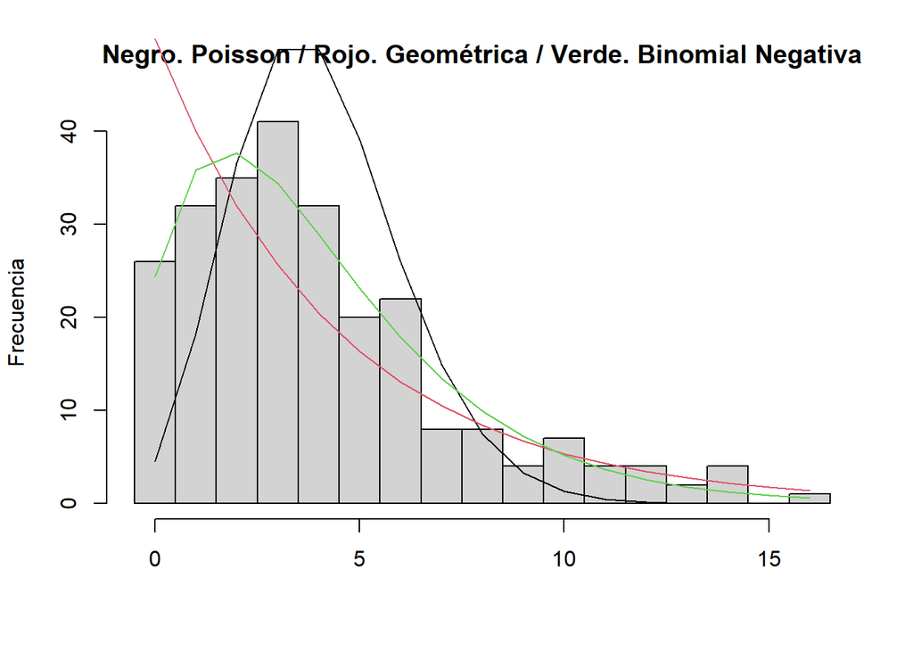

```r
par(mfrow = c(1, 1), xpd = TRUE)

a <- min(datos.ej2$x)
b <- max(datos.ej2$x)
ptos.corte <- (a - 0.5):(b + 0.5)
diagrama.pois <- hist(datos.ej2$x, breaks = ptos.corte, main = "Negro. Poisson / Rojo. Geométrica / Verde. Binomial Negativa", xlab = "", ylab = "Frecuencia")
x <- a:b
num.datos <- length(datos.ej2$x)
y.1 <- num.datos * dpois(x, lam.estp)
y.2 <- num.datos * dgeom(x, p.estg)
y.3 <- num.datos * dnbinom(x, mle.nbinom[1], mle.nbinom[2])
lines(x, y.1, col=1)
lines(x, y.2, col=2)
lines(x, y.3, col=3)
```

Mirando las gráficas podríamos decir que la distibución que mejor se ajusta a los datos es la Binomial Negativa.

## Contrastes de bondad de ajuste

```r
# Contraste del ajuste Poisson
observadas <- c(diagrama.pois$counts, 0)
probs <- c(dpois(a:b, lam.estp), 1 - sum(dpois(a:b, lam.estp)))
print(test.pois <- chisq.test(observadas, p = probs, simulate.p.value = TRUE))
```

```
##
##  Chi-squared test for given probabilities with simulated p-value (based
##  on 2000 replicates)
##
## data:  observadas
## X-squared = 2513.5, df = NA, p-value = 0.0009995
```

```r
# Contraste del ajuste Geométrica
observadas <- c(diagrama.pois$counts, 0)
probs <- c(dgeom(a:b, p.estg), 1 - sum(dgeom(a:b, p.estg)))
print(test.geom <- chisq.test(observadas, p = probs, simulate.p.value = TRUE))
```

```
##
##  Chi-squared test for given probabilities with simulated p-value (based
##  on 2000 replicates)
##
## data:  observadas
## X-squared = 47.454, df = NA, p-value = 0.0004998
```

```r
# Contraste del ajuste BN
observadas <- c(diagrama.pois$counts, 0)
probs <- c(dnbinom(a:b, mle.nbinom[1], mle.nbinom[2]), 1 - sum(dnbinom(a:b, mle.nbinom[1], mle.nbinom[2])))
print(test.nbinom <- chisq.test(observadas, p = probs, simulate.p.value = TRUE))
```

```
##
##  Chi-squared test for given probabilities with simulated p-value (based
##  on 2000 replicates)
##
## data:  observadas
## X-squared = 17.701, df = NA, p-value = 0.3973
```

Como podemos observar en los p-valor de los distintos contrastes, los ajustes Poisson y Geométrica están por encima del percentil 95 mientras que el Binomial Negativo está claramente por debajo de éste. Por tanto, como se intuía en el gráfico, el ajuste Binomial Negativo es el que mejor se ajusta a nuestros datos.

# Ejercicio 3

Dados los datos de la muestra que aparece en *ajuste.ejercicio3.txt*, se pide:

1. Estimar los parámetros de distribuciones exponencial, Gamma y normal y sus errores estándar.
2. Obtener representaciones gráficas (en la misma figura) que permitan valorar la bondad de los ajustes.
3. Realizar contrastes de bondad de ajuste para decidir cuáles de los ajustes son aceptables y cuál es el más adecuado para los datos.

## Estimación de los parámetros y sus errores estándar

Importamos los datos.

```r
datos.ej3 <- read.delim("ajusta.ejercicio3.txt")
summary(datos.ej3)
```

```
##        x
##  Min.   :0.0381
##  1st Qu.:0.2436
##  Median :0.3965
##  Mean   :0.4567
##  3rd Qu.:0.5714
##  Max.   :1.7338
```

### Exponencial

#### Estimación del parámetro

Utilizamos la fórmula conocida del estimador MLE de $\lambda$:

```r
print(lam.este <- 1 / mean(datos.ej3$x))
```

```
## [1] 2.18963
```

#### Error estándar

No tenemos fórmula para el error estándar, así que ahora lo vamos a estimar por remuestreo, como hemos hecho en la binomial negativa. Realizamos $B=200$ estimaciones simuladas a partir del remuestro de los datos y aproximamos el error estandar como la desviación típica de esas estimaciones simuladas:

```r
B <- 200
lams <- numeric()
for (i in 1:B){
  x <- sample(datos.ej3$x, replace = TRUE)
  lams[i] <- 1 / mean(x)
}
sd(lams)
```

```
## [1] 0.09285665
```

Así pues, tenemos una estimación MLE de $\lambda$ de 2.19, con un error estandar estimado de 0.09.

### Gamma

#### Estimación de los parámetros

La función de densidad es
$$f(x) = \frac{\lambda^{a} x^{a - 1} e^{-\lambda x}} {\Gamma(a)}$$

Por tanto, la función de log-verosimilitud es
$$logL(a, \lambda) = \sum_{i=1}^N ((a-1)\log(x_i) - \lambda x_i) + N(a \log{\lambda} - log(\Gamma(a)))$$

Ya sabemos que tenemos que definir el opuesto de esta función para minimizarlo con la función *optim*:

```r
# Opuesto de la log-verosimilitud
x <- datos.ej3$x
N <- length(x)
logL <- function(pars){
  a <- pars[1]
  lam <- pars[2]
  - (sum((a - 1)* log(x) - lam * x) + N * (a * log(lam) - log(gamma(a))))
}
# Valores iniciales 'sencillos'
a0 <- 1
lam0 <- 1
# Optimización
print(mle.gamma <- optim(par = c(a0, lam0), fn = logL)$par)
```

```
## [1] 2.661621 5.827878
```

### Normal

#### Estimación de los parámetros

```r
mu.est <- mean(datos.ej3$x)
sigma.est <- sum((datos.ej3$x - mu.est)^2) / length(datos.ej3$x)
print(c(mu.est, sigma.est))
```

```
## [1] 0.45669825 0.08363043
```

#### Errores estándar

Para la estimación de $\mu$ tenemos que el error estándar se aproxima con $s_{N-1} / \sqrt{N}$:

```r
print(se.mu <- sd(datos.ej3$x) / sqrt(length(datos.ej3$x)))
```

```
## [1] 0.01832662
```

pero necesitamos estimar el error estándar de $\hat{\sigma}$, y lo hacemos por remuestreo:

```r
B <- 200
sigmas <- numeric()

for (i in 1:B){
  x <- sample(datos.ej3$x, replace = TRUE)
  sigmas[i] <- sum((datos.ej3$x - mean(x))^2) / length(datos.ej3$x)
}
sd(sigmas)
```

```
## [1] 0.0005439122
```

## Bondad de los ajustes

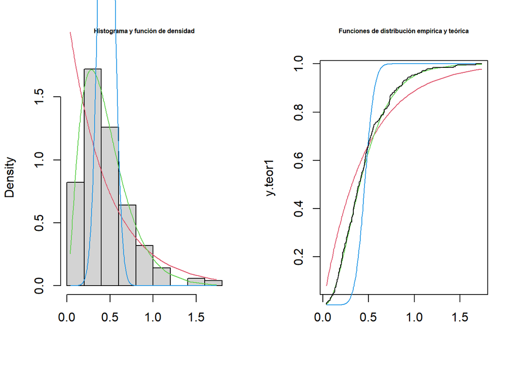

```r
par(mfrow = c(1, 2), xpd = TRUE)
#Ajuste Gamma
hist(datos.ej3$x, freq = FALSE, xlab = "", main = "Histograma y función de densidad", cex.main = 0.5)
x <- sort(datos.ej3$x)
y.dens1 <- dexp(x, lam.este)
y.dens2 <- dgamma(x, mle.gamma[1], mle.gamma[2])
y.dens3 <- dnorm(x, mu.est, sigma.est)
lines(x, y.dens1, col = 2)
lines(x, y.dens2, col = 3)
lines(x, y.dens3, col = 4)

y.teor1 <- pexp(x, lam.este)
y.teor2 <- pgamma(x, mle.gamma[1], mle.gamma[2])
y.teor3 <- pnorm(x, mu.est, sigma.est)
y.emp <- (1:length(x)) / length(x)
plot(x, y.teor1, type = 'l', col = 2, xlab = "", main = "Funciones de distribución empírica y teórica", cex.main = 0.5)
lines(x, y.teor2, col = 3)
lines(x, y.teor3, col = 4)
lines(x, y.emp, type = "S")
```

Leyenda:

- Rojo: Exponencial
- Verde: Gamma
- Azul: Normal

Observando las gráficas podemos ver como la distribución Gamma parece ser la que mejor se ajusta a nuestros datos.

## Contrastes de bondad de ajuste

```r
# Exponencial
print(dist <- ks.test(datos.ej3$x, pexp, lam.este)$statistic)
```

```
##         D
## 0.1986917
```

```r
B <- 200
N <- length(datos.ej3$x)
dists <- numeric(B)
for (i in 1:B){
  x <- rexp(N, lam.este)
  dists[i] <- ks.test(x, pexp, 1 / mean(x))$statistic
}
print(p.value <- sum(dist < dists) / B)
```

```
## [1] 0
```

```r
# Gamma
print(dist <- ks.test(datos.ej3$x, pgamma, mle.gamma[1], mle.gamma[2])$statistic)
```

```
##          D
## 0.03984144
```

```r
B <- 200
N <- length(datos.ej3$x)
dists <- numeric(B)
for (i in 1:B){
  x <- rgamma(N, mle.gamma[1], mle.gamma[2])
  logL <- function(pars){
    a <- pars[1]
    lam <- pars[2]
    - (sum((a - 1)* log(x) - lam * x) + N * (a * log(lam) - log(gamma(a))))
  }
  mle.simula <- optim(par = c(1, 1), fn = logL)$par
  dists[i] <- ks.test(x, pgamma, mle.simula[1], mle.simula[2])$statistic
}
print(p.valueg <- sum(dist < dists) / B)
```

```
## [1] 0.49
```

```r
#Normal
print(dist <- ks.test(datos.ej3$x, pnorm, mu.est, sigma.est)$statistic)
```

```
##         D
## 0.3269889
```

```r
B <- 200
N <- length(datos.ej3$x)
dists <- numeric(B)
for (i in 1:B){
  x <- rnorm(N, mu.est, sigma.est)

  mu.sim <- mean(x)
  sigma.sim <- sum((x - mu.sim)^2) / length(x)
}

print(p.value <- sum(dist < dists) / B)
```

```
## [1] 0
```

Como podemos ver, los resultados del contraste de Kolmogorov-Smirnoff nos dan un p-valor de 0 para las distribuciones Exponencial y Normal (lo que implica que son totalmente inaceptables), mientras que para la distribución Gamma el p-valor es de 0.49, muy por debajo del percentil 95 y por tanto bastante aceptable.

En conclusión, el mejor ajuste para nuestros datos es la distribución Gamma.